[figure not shown]

# Google Video Intelligence API

In this practical, we are going to learn about [Google Video Intelligence API](https://cloud.google.com/video-intelligence/). You can download and use a video file from Brightspace for the following exercises. Watch the video to familarise with the content.

Unlike Vision AI, Google does not have a demo for Video Intelligence. However, you can refer to this [Video Intelligence API Visualiser](https://zackakil.github.io/video-intelligence-api-visualiser/) to get a sense of the various types of detections offered by this API.

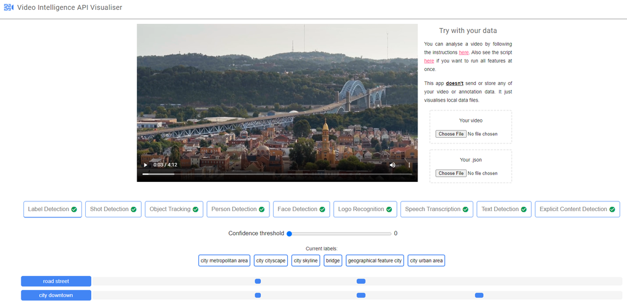

## Analyse videos for labels

The Video Intelligence API can identify entities shown in video footage using the [LABEL_DETECTION](https://cloud.google.com/video-intelligence/docs/analyze-labels) feature. This feature identifies objects, locations, activities, animal species, products, and more.

The analysis can be compartmentalized as follows:

- Frame level: Entities are identified and labeled within each frame (with one frame per second sampling).
- Shot level: Shots are automatically detected within every segment (or video). Entities are then identified and labeled within each shot.
- Segment level: User-selected segments of a video can be specified for analysis by stipulating beginning and ending time offsets for the purposes of annotation. Entities are then identified and labeled within each segment. If no segments are specified, the whole video is treated as one segment

We will set up Video Intelligence for analysis at the frame and shot level.

### Using Client Library for Video Intelligence

```python
from google.cloud import videointelligence_v1 as videointelligence
import json
import os
import io
```

```python
video_filename = 'oh_2021_short.mp4'
```

```python
# make sure file is found
!dir it3386-2024-s2.json
```

```
 Volume in drive C has no label.
 Volume Serial Number is 74EA-F427

 Directory of C:\Users\BRANDON OOI\3386_P1\P2

10/23/2024  04:06 PM             2,379 it3386-2024-s2.json
               1 File(s)          2,379 bytes
               0 Dir(s)  230,932,094,976 bytes free
```

```python
%env GOOGLE_APPLICATION_CREDENTIALS
```

```
UsageError: Environment does not have key: GOOGLE_APPLICATION_CREDENTIALS
```

```python
# set the service key in envs
%env GOOGLE_APPLICATION_CREDENTIALS=it3386-2024-s2.json
```

```
env: GOOGLE_APPLICATION_CREDENTIALS=it3386-2024-s2.json
```

```python
%env GOOGLE_APPLICATION_CREDENTIALS
```

```
'it3386-2024-s2.json'
```

```python
# https://cloud.google.com/video-intelligence/docs/analyze-labels
def analyze_label(path):

    #segment1=videointelligence.VideoSegment(
    #    start_time_offset={"seconds":1},
    #    end_time_offset={"seconds":3}
    #)

    video_client = videointelligence.VideoIntelligenceServiceClient()
    features = [videointelligence.Feature.LABEL_DETECTION]

    mode = videointelligence.LabelDetectionMode.SHOT_AND_FRAME_MODE
    config = videointelligence.LabelDetectionConfig(label_detection_mode=mode)

    context = videointelligence.VideoContext(label_detection_config=config)

    #context = videointelligence.VideoContext(label_detection_config=config, segments=[segment1])

    with io.open(path, "rb") as movie:
        input_content = movie.read()

    operation = video_client.annotate_video(
        request={"features": features, "input_content": input_content, "video_context": context}
    )
    print("\nProcessing video for label annotations:")


    result = operation.result(timeout=300)
    print("\nFinished processing.")

    # Process video/segment level label annotations
    segment_labels = result.annotation_results[0].segment_label_annotations
    for i, segment_label in enumerate(segment_labels):
        print("Video label description: {}".format(segment_label.entity.description))
        for category_entity in segment_label.category_entities:
            print(
                "\tLabel category description: {}".format(category_entity.description)
            )

        for i, segment in enumerate(segment_label.segments):
            start_time = (
                segment.segment.start_time_offset.seconds
                + segment.segment.start_time_offset.microseconds / 1e6
            )
            end_time = (
                segment.segment.end_time_offset.seconds
                + segment.segment.end_time_offset.microseconds / 1e6
            )
            positions = "{}s to {}s".format(start_time, end_time)
            confidence = segment.confidence
            print("\tSegment {}: {}".format(i, positions))
            print("\tConfidence: {}".format(confidence))
        print("\n")

    # Process shot level label annotations
    shot_labels = result.annotation_results[0].shot_label_annotations
    for i, shot_label in enumerate(shot_labels):
        print("Shot label description: {}".format(shot_label.entity.description))
        for category_entity in shot_label.category_entities:
            print(
                "\tLabel category description: {}".format(category_entity.description)
            )

        for i, shot in enumerate(shot_label.segments):
            start_time = (
                shot.segment.start_time_offset.seconds
                + shot.segment.start_time_offset.microseconds / 1e6
            )
            end_time = (
                shot.segment.end_time_offset.seconds
                + shot.segment.end_time_offset.microseconds / 1e6
            )
            positions = "{}s to {}s".format(start_time, end_time)
            confidence = shot.confidence
            print("\tSegment {}: {}".format(i, positions))
            print("\tConfidence: {}".format(confidence))
        print("\n")

    # Process frame level label annotations
    frame_labels = result.annotation_results[0].frame_label_annotations
    for i, frame_label in enumerate(frame_labels):
        print("Frame label description: {}".format(frame_label.entity.description))
        for category_entity in frame_label.category_entities:
            print(
                "\tLabel category description: {}".format(category_entity.description)
            )

        # Each frame_label_annotation has many frames,
        # here we print information only about the first frame.
        frame = frame_label.frames[0]
        time_offset = frame.time_offset.seconds + frame.time_offset.microseconds / 1e6
        print("\tFirst frame time offset: {}s".format(time_offset))
        print("\tFirst frame confidence: {}".format(frame.confidence))
        print("\n")

    return result
```

```python
# shot and frame labels
result_label = analyze_label(video_filename)
```

```
Processing video for label annotations:

Finished processing.
Shot label description: desktop computer
	Label category description: computer
	Segment 0: 23.8s to 25.0s
	Confidence: 0.34185412526130676


Shot label description: presentation
	Label category description: person
	Segment 0: 18.16s to 20.2s
	Confidence: 0.5722100138664246
	Segment 1: 22.72s to 23.76s
	Confidence: 0.7202422022819519


Shot label description: display device
	Label category description: technology
	Segment 0: 23.8s to 25.0s
	Confidence: 0.4997156262397766


Shot label description: media
	Segment 0: 23.8s to 25.0s
	Confidence: 0.5530117154121399


Shot label description: flat panel display
	Label category description: technology
	Segment 0: 23.8s to 25.0s
	Confidence: 0.6134250164031982


Shot label description: meeting
	Label category description: event
	Segment 0: 22.72s to 23.76s
	Confidence: 0.4649142920970917


```

[output cut: 887 more lines]

```
	Label category description: person
	First frame time offset: 7.0s
	First frame confidence: 0.6952177882194519


Frame label description: business school
	Label category description: school
	First frame time offset: 23.0s
	First frame confidence: 0.43678176403045654


Frame label description: flat panel display
	Label category description: technology
	First frame time offset: 24.0s
	First frame confidence: 0.5645241141319275
```

```python
frame_labels = result_label.annotation_results[0].frame_label_annotations
```

```python
# print one random frame and analyse the keys and values
frame_labels[1]
```

```
entity {
  entity_id: "/m/0qb7t"
  description: "organization"
  language_code: "en-US"
}
frames {
  time_offset {
    seconds: 20
  }
  confidence: 0.412864089012146
}
frames {
  time_offset {
    seconds: 23
  }
  confidence: 0.45194539427757263
}
```

```python
print(frame_labels[1].frames)
```

```
[time_offset {
  seconds: 20
}
confidence: 0.412864089012146
, time_offset {
  seconds: 23
}
confidence: 0.45194539427757263
]
```

### Explore the frames

Entities are identified and labeled within each frame (with one frame per second sampling).

```python
# explore the first label
frame_labels[0]
```

```
entity {
  entity_id: "/m/0dwx7"
  description: "logo"
  language_code: "en-US"
}
category_entities {
  entity_id: "/m/021sdg"
  description: "graphics"
  language_code: "en-US"
}
frames {
  time_offset {
  }
  confidence: 0.627734899520874
}
frames {
  time_offset {
    seconds: 1
  }
  confidence: 0.6281653642654419
}
frames {
  time_offset {
    seconds: 2
  }
  confidence: 0.6281343102455139
}
frames {
  time_offset {
    seconds: 3
  }
  confidence: 0.5801541805267334
}
```

Let's consolidate the frames and entities under `records`

```python
records = []
for label in frame_labels:
    #print(label)
    record = {'entity':'', 'category':'', 'frame':'', 'confidence':''}
    list_frames = []
    list_confidence = []
    list_categories = []
    list_entities = []

    record['entity'] = label.entity.description
    for cat_ent in label.category_entities:
        list_categories.append(cat_ent.description)
    record['category'] = ','.join(list_categories)

    for frame in label.frames:
        list_frames.append(str(frame.time_offset))
        list_confidence.append(str(round(frame.confidence*100)))

    record['frame'] = ','.join(list_frames)
    record['confidence'] = ','.join(list_confidence)
    records.append(record)

    '''
    record['entity'] = label.entity.description
    if 'category_entities' in label:
        for category in label.categoryEntities:
            list_categories.append(category.description)

    record['category'] = ','.join(list_categories)

    for frame in label.frames:
        list_frames.append(frame.timeOffset)
        list_confidence.append(str(round(frame.confidence*100)))
    '''
```

```python
print(records)
```

[output not shown]

```python
# explore first element
records[0]
```

```
{'entity': 'logo',
 'category': 'graphics',
 'frame': '0:00:00,0:00:01,0:00:02,0:00:03',
 'confidence': '63,63,63,58'}
```

```python
from IPython.display import HTML, display

html = '<table><thead><tr><th>Entity</th><th>Category</th><th>Frame At</th><th>Confidence (%)</th></tr></thead><tbody>'

for record in records:
    entity = record['entity']
    category = record['category'].replace(',', '<br>')
    frame = record['frame'].replace(',', '<br>')
    confidence = record['confidence'].replace(',', '<br>')
    row = '<tr style="vertical-align:top"><td>{}</td><td>{}</td><td>{}</td><td>{}</td></tr>'.format(entity, category, frame, confidence)
    html = html + row
    #break

html = html + '</tbody></table>'
display(HTML(html))
```

| Entity | Category | Frame At | Confidence (%) |
| --- | --- | --- | --- |
| logo | graphics | 0:00:00 0:00:01 0:00:02 0:00:03 | 63 63 63 58 |
| organization |  | 0:00:20 0:00:23 | 41 45 |
| human leg | human body | 0:00:12 | 68 |
| darkness |  | 0:00:00 0:00:01 0:00:02 0:00:03 | 85 85 85 87 |
| selfie | photography | 0:00:13 | 42 |
| indoor games and sports | games sports | 0:00:08 | 70 |
| professional | person | 0:00:04 0:00:05 0:00:06 0:00:08 0:00:13 0:00:17 0:00:18 0:00:19 0:00:20 0:00:21 0:00:22 0:00:23 0:00:26 0:00:27 0:00:28 | 78 76 77 51 41 60 62 59 63 50 81 41 57 52 46 |
| computer | technology | 0:00:17 0:00:18 0:00:19 0:00:20 0:00:21 0:00:23 0:00:24 0:00:25 0:00:26 | 73 72 70 70 68 65 48 53 56 |
| performance | event entertainment | 0:00:08 0:00:15 0:00:27 0:00:28 | 65 74 47 68 |
| event |  | 0:00:09 0:00:11 0:00:15 0:00:16 0:00:27 0:00:28 | 55 48 78 47 48 50 |
| structure |  | 0:00:12 | 83 |
| programmer | professional | 0:00:17 0:00:18 0:00:26 | 52 56 51 |
| meeting | event | 0:00:21 0:00:23 | 40 59 |
| electronic device | technology | 0:00:07 0:00:09 0:00:13 0:00:16 0:00:17 0:00:18 0:00:19 0:00:20 0:00:21 0:00:22 0:00:23 0:00:24 0:00:25 0:00:26 | 43 87 80 74 90 91 83 83 81 50 73 90 92 91 |
| line | shape | 0:00:00 0:00:01 0:00:02 0:00:03 | 79 79 79 78 |
| media |  | 0:00:24 0:00:25 0:00:26 | 58 64 41 |
| midnight |  | 0:00:00 0:00:01 0:00:02 0:00:03 | 57 57 57 60 |
| material |  | 0:00:11 0:00:15 | 59 62 |
| gym | room | 0:00:12 | 76 |
| software |  | 0:00:24 0:00:25 | 79 79 |
| world |  | 0:00:04 0:00:05 0:00:06 0:00:07 0:00:11 0:00:15 | 43 44 42 43 46 42 |
| long hair | hair | 0:00:14 | 66 |
| communication device | technology | 0:00:17 0:00:19 0:00:20 0:00:23 | 50 69 73 86 |
| projector | technology | 0:00:19 0:00:20 0:00:23 | 41 56 47 |
| point | shape | 0:00:00 0:00:01 0:00:02 0:00:03 | 47 47 47 42 |
| fun |  | 0:00:04 0:00:05 0:00:06 0:00:07 0:00:08 0:00:09 0:00:11 0:00:13 0:00:14 0:00:15 0:00:16 0:00:27 | 54 54 51 63 64 64 47 66 51 75 57 53 |
| exercise equipment |  | 0:00:12 | 80 |
| graphics | artwork | 0:00:00 0:00:01 0:00:02 0:00:03 | 62 62 62 62 |
| snapshot | photography photograph | 0:00:07 | 82 |
| smile | person | 0:00:04 0:00:05 0:00:06 0:00:07 0:00:13 0:00:14 0:00:22 | 49 43 62 82 55 57 46 |

[output cut: 98 more lines]

### Todo

> Use tools like Photos or VLC to play the video at certain frames to determine if the detections are accurate.

### Explore the Shots

Shots are automatically detected within every segment (or video). Entities are then identified and labeled within each shot.

```python
result_label.annotation_results[0].shot_label_annotations
```

```
[entity {
  entity_id: "/m/0dvvc"
  description: "desktop computer"
  language_code: "en-US"
}
category_entities {
  entity_id: "/m/01m3v"
  description: "computer"
  language_code: "en-US"
}
segments {
  segment {
    start_time_offset {
      seconds: 23
      nanos: 800000000
    }
    end_time_offset {
      seconds: 25
    }
  }
  confidence: 0.34185412526130676
}
, entity {
  entity_id: "/m/02y3rj"
  description: "presentation"
  language_code: "en-US"
}
category_entities {
  entity_id: "/m/01g317"
  description: "person"
  language_code: "en-US"
}
segments {
  segment {
    start_time_offset {
      seconds: 18
      nanos: 160000000
    }
    end_time_offset {
      seconds: 20
```

[output cut: 732 more lines]

```
  language_code: "en-US"
}
segments {
  segment {
    start_time_offset {
      seconds: 23
      nanos: 800000000
    }
    end_time_offset {
      seconds: 25
    }
  }
  confidence: 0.669050395488739
}
]
```

```python
label_shots = result_label.annotation_results[0].shot_label_annotations
```

```python
# Explore first element
label_shots[0]
```

```
entity {
  entity_id: "/m/0dvvc"
  description: "desktop computer"
  language_code: "en-US"
}
category_entities {
  entity_id: "/m/01m3v"
  description: "computer"
  language_code: "en-US"
}
segments {
  segment {
    start_time_offset {
      seconds: 23
      nanos: 800000000
    }
    end_time_offset {
      seconds: 25
    }
  }
  confidence: 0.34185412526130676
}
```

```python
# find a label with more than 1 segment
label_shots[1]
```

```
entity {
  entity_id: "/m/02y3rj"
  description: "presentation"
  language_code: "en-US"
}
category_entities {
  entity_id: "/m/01g317"
  description: "person"
  language_code: "en-US"
}
segments {
  segment {
    start_time_offset {
      seconds: 18
      nanos: 160000000
    }
    end_time_offset {
      seconds: 20
      nanos: 200000000
    }
  }
  confidence: 0.5722100138664246
}
segments {
  segment {
    start_time_offset {
      seconds: 22
      nanos: 720000000
    }
    end_time_offset {
      seconds: 23
      nanos: 760000000
    }
  }
  confidence: 0.7202422022819519
}
```

Each segment label includes a description, a list of entity categories, and a list of segments identifying the start/end time of the label occurrences in the video.

```python
for idx, label in enumerate(label_shots):
    #print(label)
    print('{} Entity: {}'.format(idx, label.entity.description))
    #if 'categoryEntities' in label:
    for category in label.category_entities:
        print('Category: {}'.format(category.description))

    # no need to break up segment first
    for segment in label.segments:
        print('Start Time Offset: {}'.format(segment.segment.start_time_offset))
        print('End Time Offset: {}'.format(segment.segment.end_time_offset))
        print('Confidence: {}'.format(segment.confidence))

    print('\n')
```

```
0 Entity: desktop computer
Category: computer
Start Time Offset: 0:00:23.800000
End Time Offset: 0:00:25
Confidence: 0.34185412526130676


1 Entity: presentation
Category: person
Start Time Offset: 0:00:18.160000
End Time Offset: 0:00:20.200000
Confidence: 0.5722100138664246
Start Time Offset: 0:00:22.720000
End Time Offset: 0:00:23.760000
Confidence: 0.7202422022819519


2 Entity: display device
Category: technology
Start Time Offset: 0:00:23.800000
End Time Offset: 0:00:25
Confidence: 0.4997156262397766


3 Entity: media
Start Time Offset: 0:00:23.800000
End Time Offset: 0:00:25
Confidence: 0.5530117154121399


4 Entity: flat panel display
Category: technology
Start Time Offset: 0:00:23.800000
End Time Offset: 0:00:25
Confidence: 0.6134250164031982


5 Entity: meeting
Category: event
Start Time Offset: 0:00:22.720000
```

[output cut: 190 more lines]

```
Confidence: 0.46226081252098083


32 Entity: lcd tv
Category: television
Start Time Offset: 0:00:23.800000
End Time Offset: 0:00:25
Confidence: 0.5463842153549194


33 Entity: led backlit lcd display
Category: technology
Start Time Offset: 0:00:23.800000
End Time Offset: 0:00:25
Confidence: 0.669050395488739
```

### Analyse the predictions

Based on the shots detected in the video, extract a few frames to display and see if the prediction is accurate.

```python
# create an output directory to hold the generated files
dir_output = 'output'
if not os.path.isdir(dir_output):
    os.makedirs(dir_output)
```

```python
# Use conda to manage dependencies across packages
# conda installation is done outside notebook in Anaconda prompt
# conda install -c conda-forge moviepy
```

```python
from moviepy.editor import VideoFileClip, concatenate_videoclips
from pathlib import Path

# entity will be the filename
def get_gif_and_mp4_filename(video_source_filename, start_time, stop_time, entity):
    output_filename_video = str(Path(dir_output + '/' + entity.replace(' ', '_') + '.mp4'))
    output_filename_gif = str(Path(dir_output + '/' + entity.replace(' ', '_') + '.gif'))

    clip = VideoFileClip(video_source_filename, audio=False).subclip(start_time, stop_time)
    clip.write_videofile(output_filename_video)
    clip.close()

    clip_segment = VideoFileClip(output_filename_video, audio=False)
    clip_segment.write_gif(output_filename_gif)
    return output_filename_gif, output_filename_video
```

```python
print(video_filename)
```

```
oh_2021_short.mp4
```

```python
# choose an index
index = 8
print(label_shots[index])
time_offset_start = label_shots[index].segments[0].segment.start_time_offset.seconds
time_offset_end = label_shots[index].segments[0].segment.end_time_offset.seconds

entity_description = label_shots[index].entity.description
print(entity_description)
```

```
entity {
  entity_id: "/m/02522"
  description: "computer monitor"
  language_code: "en-US"
}
category_entities {
  entity_id: "/m/07c1v"
  description: "technology"
  language_code: "en-US"
}
segments {
  segment {
    start_time_offset {
      seconds: 23
      nanos: 800000000
    }
    end_time_offset {
      seconds: 25
    }
  }
  confidence: 0.8510110378265381
}

computer monitor
```

```python
print(time_offset_start)
```

[output not shown]

```python
'''
Example entity

Entity: lecture
Start Time Offset: 22.720s
End Time Offset: 23.760s
'''

from IPython import display

filename_gif, filename_mp4 = get_gif_and_mp4_filename(video_filename, time_offset_start, time_offset_end, entity_description)
```

```
Moviepy - Building video output\computer_monitor.mp4.
Moviepy - Writing video output\computer_monitor.mp4
```

```
Moviepy - Done !
Moviepy - video ready output\computer_monitor.mp4
MoviePy - Building file output\computer_monitor.gif with imageio.
```

```python
# takes a while to display the gif
display.Image(filename_gif, width=320)
```

[output not shown]

Alternatively, we can export and explore the frames

```python
clip_segment = VideoFileClip(filename_mp4)
clip_segment.write_images_sequence('output/frame%04d.jpg', verbose=True)
```

```
Moviepy - Writing frames output/frame%04d.jpg.
```

```
Moviepy - Done writing frames output/frame%04d.jpg.
```

```
['output/frame0000.jpg',
 'output/frame0001.jpg',
 'output/frame0002.jpg',
 'output/frame0003.jpg',
 'output/frame0004.jpg',
 'output/frame0005.jpg',
 'output/frame0006.jpg',
 'output/frame0007.jpg',
 'output/frame0008.jpg',
 'output/frame0009.jpg',
 'output/frame0010.jpg',
 'output/frame0011.jpg',
 'output/frame0012.jpg',
 'output/frame0013.jpg',
 'output/frame0014.jpg',
 'output/frame0015.jpg',
 'output/frame0016.jpg',
 'output/frame0017.jpg',
 'output/frame0018.jpg',
 'output/frame0019.jpg',
 'output/frame0020.jpg',
 'output/frame0021.jpg',
 'output/frame0022.jpg',
 'output/frame0023.jpg',
 'output/frame0024.jpg',
 'output/frame0025.jpg',
 'output/frame0026.jpg',
 'output/frame0027.jpg',
 'output/frame0028.jpg',
 'output/frame0029.jpg',
 'output/frame0030.jpg',
 'output/frame0031.jpg',
 'output/frame0032.jpg',
 'output/frame0033.jpg',
 'output/frame0034.jpg',
 'output/frame0035.jpg',
 'output/frame0036.jpg',
 'output/frame0037.jpg',
 'output/frame0038.jpg',
 'output/frame0039.jpg',
 'output/frame0040.jpg',
 'output/frame0041.jpg',
 'output/frame0042.jpg',
 'output/frame0043.jpg',
 'output/frame0044.jpg',
 'output/frame0045.jpg',
 'output/frame0046.jpg',
 'output/frame0047.jpg',
 'output/frame0048.jpg',
 'output/frame0049.jpg']
```

```
computer monitor
```

[figure not shown]

```python
print(entity_description)
display.Image('output/frame0023.jpg', width=320)
```

### Todo

> Display more frames? Are the predictions accurate?

Ref

- https://videointelligence.googleapis.com/v1/videos:annotate
- https://cloud.google.com/video-intelligence/docs/label-tutorial